# Auto Interpolation Library For R

```r
# First we make sure that devtools is installed on your R envirnoment
if (!require(devtools)) {
  install.packages('devtools')
}
# Then we can install my script by running the following command
devtools::install_github('Moustapha-A/autopolate')
```

First we intall the package from github using devtools::install_github

```r
library(autopolate)
```

Then we load the library as any other library

### *Treating Neat Data*

```r
data("EZ68")
EZ68 = na.omit(EZ68)
```

Now we will load some data that belongs to one of polluscope’s campaigns. Using the Ecomzen 68 sensor.

```r
head(EZ68,10)
```

```
##             Date (UTC)   Temp     RH Pressure    NO2    O3    COV   PMP
## 2  2017-09-21 07:27:52 17.678 53.603 1016.806 34.487 0.000 58.525 0.000
## 3  2017-09-21 07:29:54 17.741 52.622 1016.824 34.487 0.000 58.525 0.000
## 4  2017-09-21 07:30:57 17.786 52.858 1016.727 34.487 0.000 58.525 0.000
## 5  2017-09-21 07:32:57 17.830 50.521 1016.781 32.758 0.138 55.466 1.983
## 6  2017-09-21 07:33:51 17.813 50.335 1016.819 31.718 0.699 54.701 4.845
## 7  2017-09-21 07:35:57 17.589 49.513 1017.015 31.025 0.583 55.247 5.175
## 8  2017-09-21 07:36:51 17.482 49.639 1017.101 31.025 0.583 53.062 5.175
## 9  2017-09-21 07:37:51 17.401 49.779 1017.153 28.411 0.437 53.426 5.883
## 10 2017-09-21 07:38:52 17.240 50.008 1017.163 28.411 0.437 53.426 5.883
## 11 2017-09-21 07:39:56 17.169 50.211 1017.187 26.489 0.350 55.744 6.565
##     Latitude Longitude  Altitude GPS Date
## 2  No signal No signal No signal 23:59:49
## 3  No signal No signal No signal 23:59:49
## 4  No signal No signal No signal 00:00:40
## 5  No signal No signal No signal 23:59:49
## 6  No signal No signal No signal 23:59:49
## 7  No signal No signal No signal 23:59:49
## 8  No signal No signal No signal 07:36:09
## 9  No signal No signal No signal 07:37:09
## 10 No signal No signal No signal 07:38:10
## 11 No signal No signal No signal 07:39:13
```

The first 10 records of EZ68

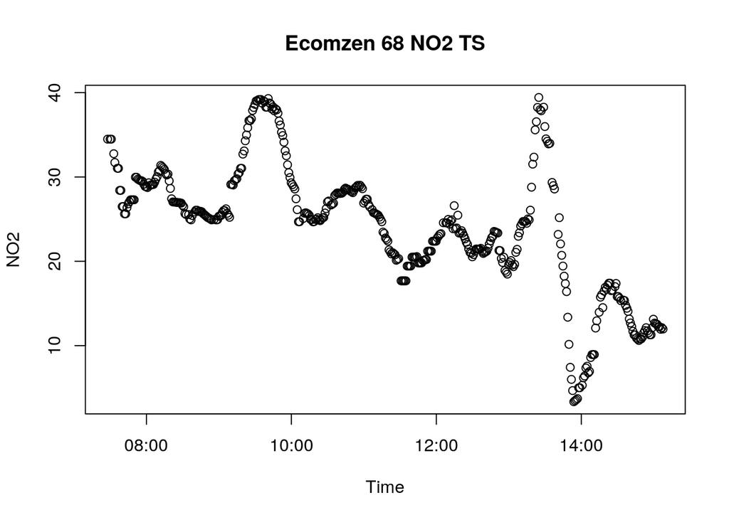

```r
plot(as.POSIXct(EZ68$`Date (UTC)`,format="%Y-%m-%d %H:%M:%S"),EZ68$NO2, main = "Ecomzen 68 NO2 TS", xlab = "Time", ylab = "NO2")
```

The plot of NO2 against Time

We can see that the aquisition rate of Ecomzen is not stable sometimes it is ~1 min other is ~2 min. What we want to do is to have the values at a stable rate. Let us say that we need to have the data as a rate of 30 seconds. We will do that using the *autopolate* function I developed:

```r
NO2_ts= autopolate(dataframe = EZ68,
                  timeCol = "Date (UTC)",
                  timeFrmt = "%Y-%m-%d %H:%M:%S",
                  valueCol = "NO2",
                  targetRate = 30)
```

```r
head(NO2_ts,10)
```

```
##             Date (UTC)      NO2
## 1  2017-09-21 07:27:52 34.58328
## 2  2017-09-21 07:28:22 34.59857
## 3  2017-09-21 07:28:52 34.57463
## 4  2017-09-21 07:29:22 34.51265
## 5  2017-09-21 07:29:52 34.41382
## 6  2017-09-21 07:30:22 34.27932
## 7  2017-09-21 07:30:52 34.11033
## 8  2017-09-21 07:31:22 33.90804
## 9  2017-09-21 07:31:52 33.67364
## 10 2017-09-21 07:32:22 33.40829
```

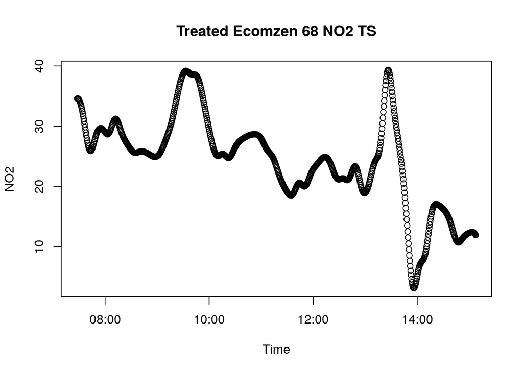

```r
plot(NO2_ts$`Date (UTC)`,NO2_ts$NO2, main = "Treated Ecomzen 68 NO2 TS", xlab = "Time", ylab = "NO2")
```

However it is alwayse preferable to check the quality of the data interpolation before using and considering it. That is why I added some metrics to be included in the interpolation process. Those metrics are *The Root Mean Squared Error (RMSE)*, the plot of the initial data against the interpolated curves, and the plot of the residuals. Those can be used by adding *plot=TRUE* , *residuals=TRUE* and *RMSE=TRUE*.

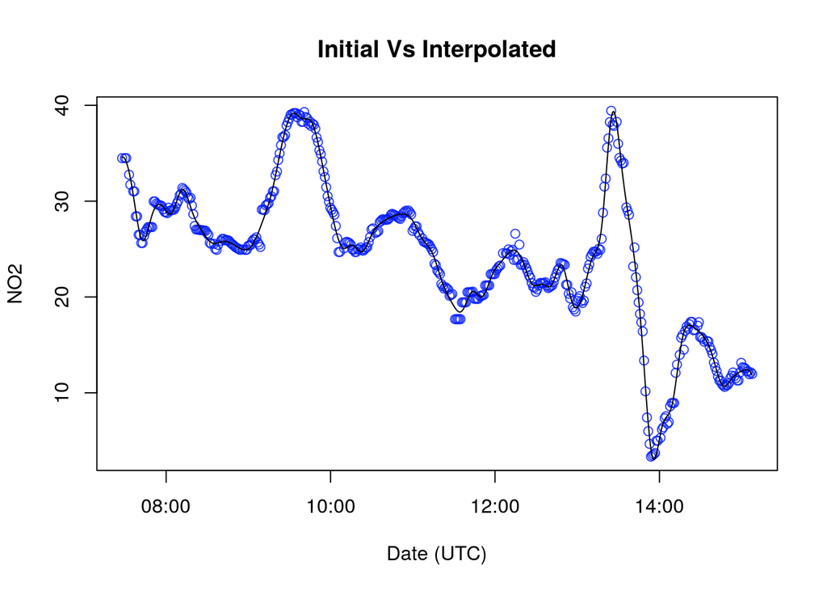

```
## [1] "##################### RMSE #####################"
## [1] "RMSE of function  1  :  0.53878735145198"
## [1] "Average RMSE :  0.53878735145198"
```

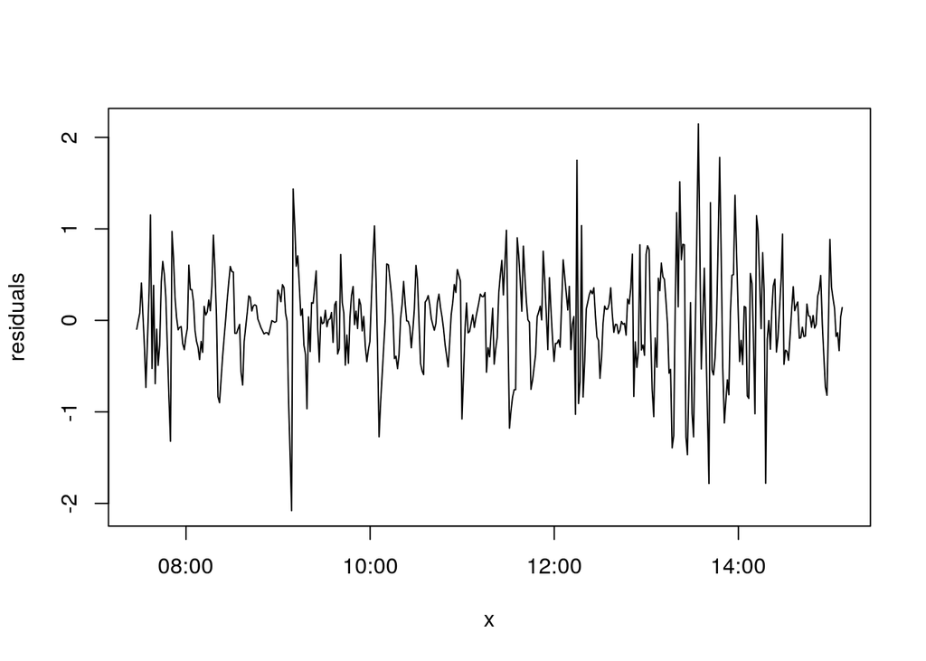

```r
NO2_ts= autopolate(dataframe = EZ68,
                  timeCol = "Date (UTC)",
                  timeFrmt = "%Y-%m-%d %H:%M:%S",
                  valueCol = "NO2",
                  targetRate = 30,
                  plot=TRUE,
                  residual = TRUE,
                  RMSE = TRUE)
```

```r
NO2_ts= autopolate(dataframe = EZ68,
                  timeCol = "Date (UTC)",
                  timeFrmt = "%Y-%m-%d %H:%M:%S",
                  valueCol = "NO2",
                  targetRate = 30,
                  plot=TRUE,
                  residual = TRUE,
                  interactive = TRUE,
                  RMSE = TRUE)
```

```
## [1] "##################### RMSE #####################"
## [1] "RMSE of function  1  :  0.53878735145198"
## [1] "Average RMSE :  0.53878735145198"
```

The data scientist can alwayse add the *interactive=TRUE* argument to have interactive plots. However this requires the plotly package to be installed.

```r
NO2_ts= autopolate(dataframe = EZ68,
                  timeCol = "Date (UTC)",
                  timeFrmt = "%Y-%m-%d %H:%M:%S",
                  valueCol = "NO2",
                  targetRate = 30,
                  basisRatio = 0.5,
                  plot=TRUE,
                  residual = TRUE,
                  interactive = TRUE,
                  RMSE = TRUE)
```

```
## [1] "##################### RMSE #####################"
## [1] "RMSE of function  1  :  0.28318848383448"
## [1] "Average RMSE :  0.28318848383448"
```

To achieve more fitting to data the user can use the *basisRatio* argument to increase the number of basis functions. If it is not specified it is default is 0.1 . Which means 0.1 of the initial data in our case we have 441 data records so the default number of basis function is 0.1*441 = 45 basis functions. In the above example we used a basisRatio=0.5 i.e. 0.5*441 = 221 basis function. we can see the difference in the average RMSE beteen interpolating using 45 and 221 basis functions.